# Data Exploration

#### 2.21 migration_sunbelt

almost same distribution for the income level between the categories

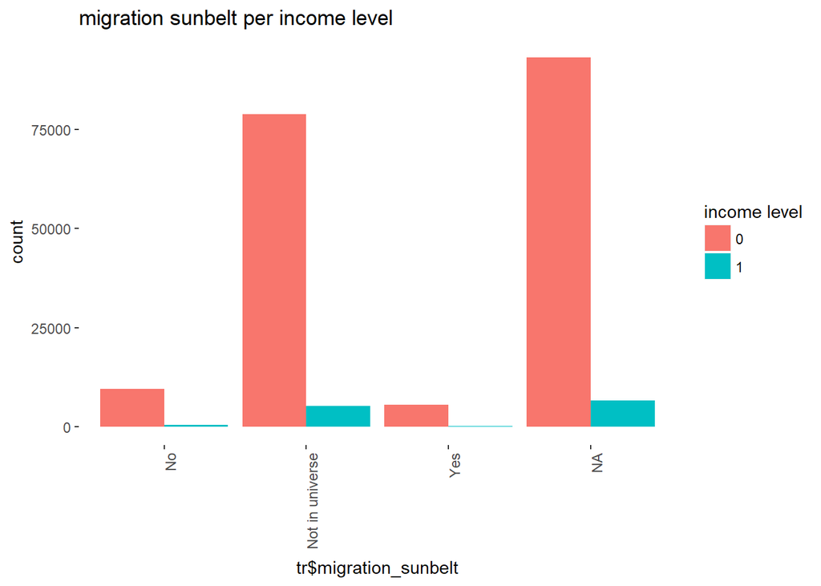

```r
ggplot(tr,aes(x = tr$migration_sunbelt, fill = as.factor(income_level))) + geom_bar(position="dodge")+theme(panel.background = element_blank(),axis.text.x =element_text(angle  = 90,hjust = 1,size=9))+
  ggtitle("migration sunbelt per income level")+labs(fill = "income level")
```

#### 2.22 family_members_under_18

We can ignore this variable as we can depend on the age variable for the same pattern (all children have income level 0)

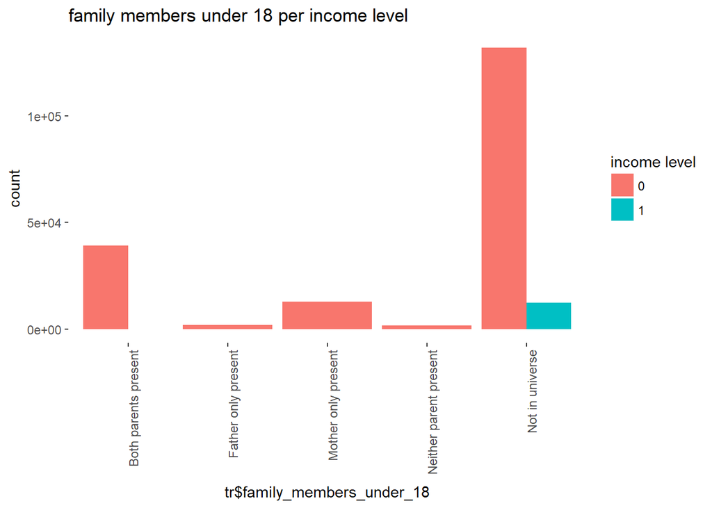

```r
ggplot(tr,aes(x = tr$family_members_under_18, fill = as.factor(income_level))) + geom_bar(position="dodge")+theme(panel.background = element_blank(),axis.text.x =element_text(angle  = 90,hjust = 1,size=9))+
  ggtitle("family members under 18 per income level")+labs(fill = "income level")
```

#### 2.23 country_father

While Europe has slightly better percentage for income level 1, Central and South America has no people with income level 1

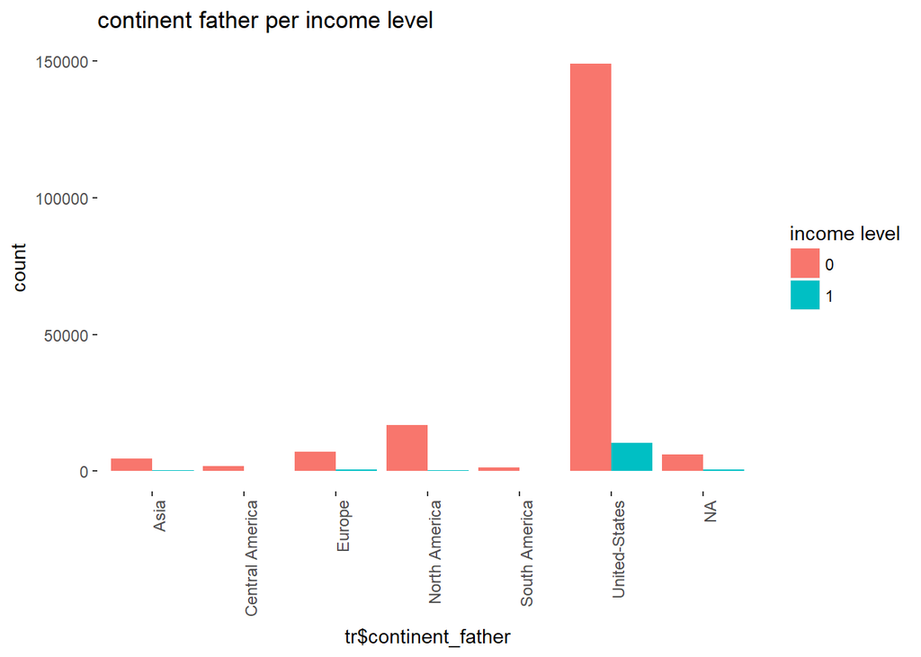

```r
ggplot(tr,aes(x = tr$continent_father, fill = as.factor(income_level))) + geom_bar(position="dodge")+theme(panel.background = element_blank(),axis.text.x =element_text(angle  = 90,hjust = 1,size=9))+
  ggtitle("continent father per income level")+labs(fill = "income level")
```

#### 2.24 country_mother

As same as the country father variable, Eourpe has slightly better percentage for income level 1, Central and South America has no people with income level 1

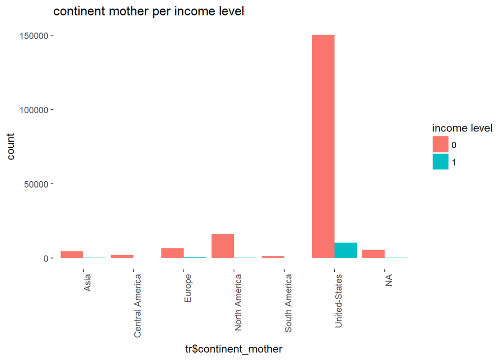

```r
ggplot(tr,aes(x = tr$continent_mother, fill = as.factor(income_level))) + geom_bar(position="dodge")+theme(panel.background = element_blank(),axis.text.x =element_text(angle  = 90,hjust = 1,size=9))+
  ggtitle("continent mother per income level")+labs(fill = "income level")
```

#### 2.25 country_self

central and South America has no people with income level 1, while the others has almost the same distribution regarding the income level

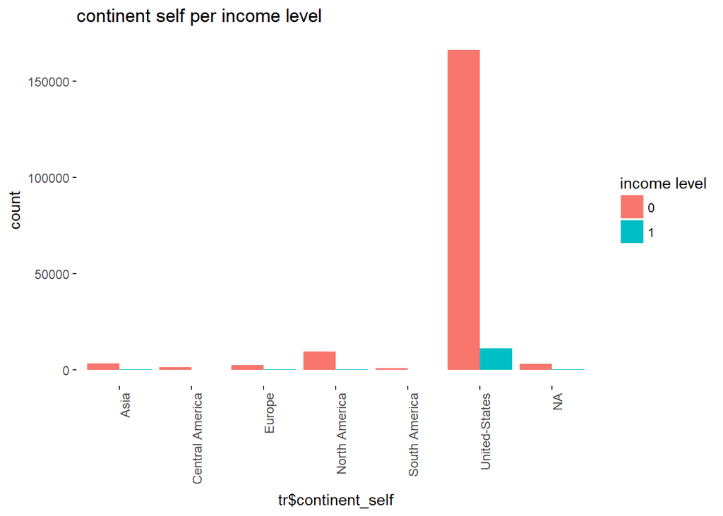

```r
ggplot(tr,aes(x = tr$continent_self, fill = as.factor(income_level))) + geom_bar(position="dodge")+theme(panel.background = element_blank(),axis.text.x =element_text(angle  = 90,hjust = 1,size=9))+
  ggtitle("continent self per income level")+labs(fill = "income level")
```

#### 2.26 citizenship

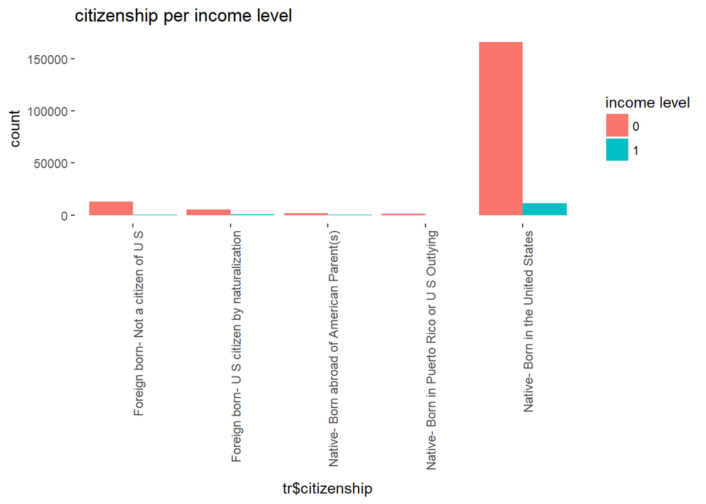

```r
ggplot(tr,aes(x = tr$citizenship, fill = as.factor(income_level))) + geom_bar(position="dodge")+theme(panel.background = element_blank(),axis.text.x =element_text(angle  = 90,hjust = 1,size=9))+
  ggtitle("citizenship per income level")+labs(fill = "income level")
```

#### 2.27 business_or_self_employed

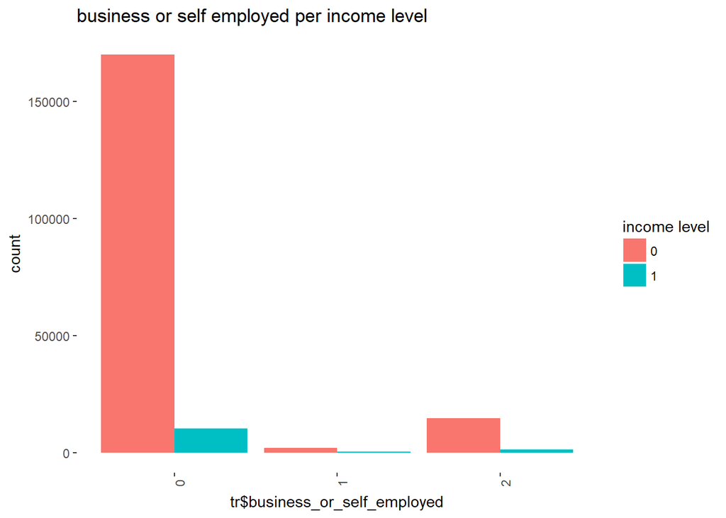

```r
ggplot(tr,aes(x = tr$business_or_self_employed, fill = as.factor(income_level))) + geom_bar(position="dodge")+theme(panel.background = element_blank(),axis.text.x =element_text(angle  = 90,hjust = 1,size=9))+
  ggtitle("business or self employed per income level")+labs(fill = "income level")
```

#### 2.28 fill_questionnaire_veteran_admin

More than 97% of the data fall into one category, we will not consider this variable for our model

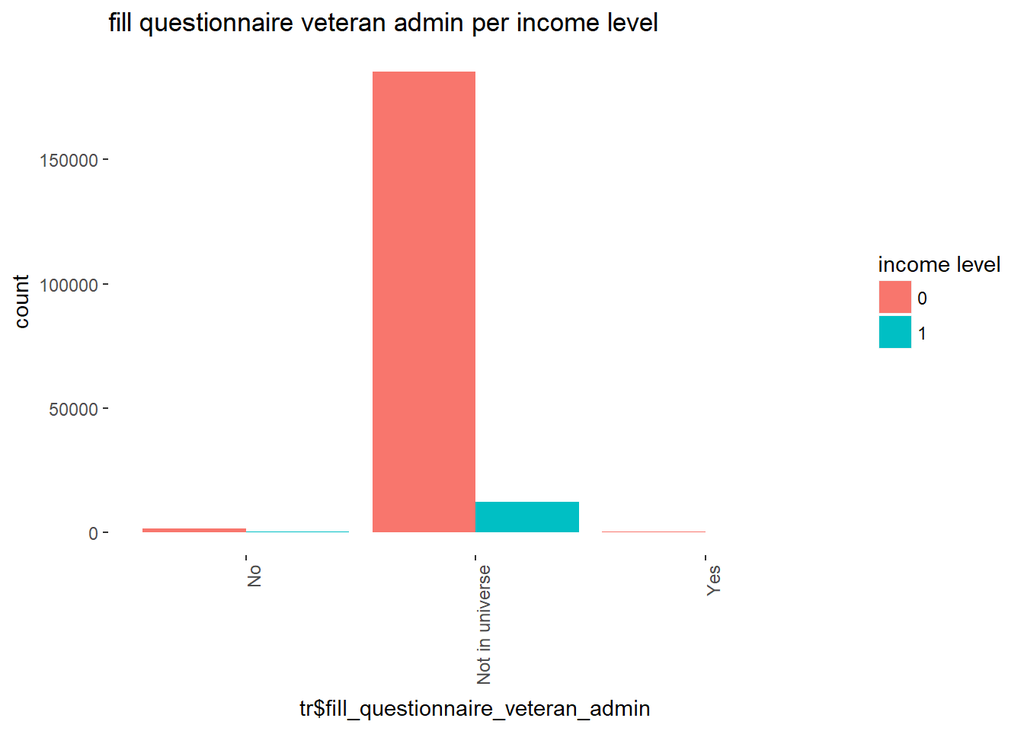

```r
ggplot(tr,aes(x = tr$fill_questionnaire_veteran_admin, fill = as.factor(income_level))) + geom_bar(position="dodge")+theme(panel.background = element_blank(),axis.text.x =element_text(angle  = 90,hjust = 1,size=9))+
  ggtitle("fill questionnaire veteran admin per income level")+labs(fill = "income level")
```

#### 2.29 veterans_benefits

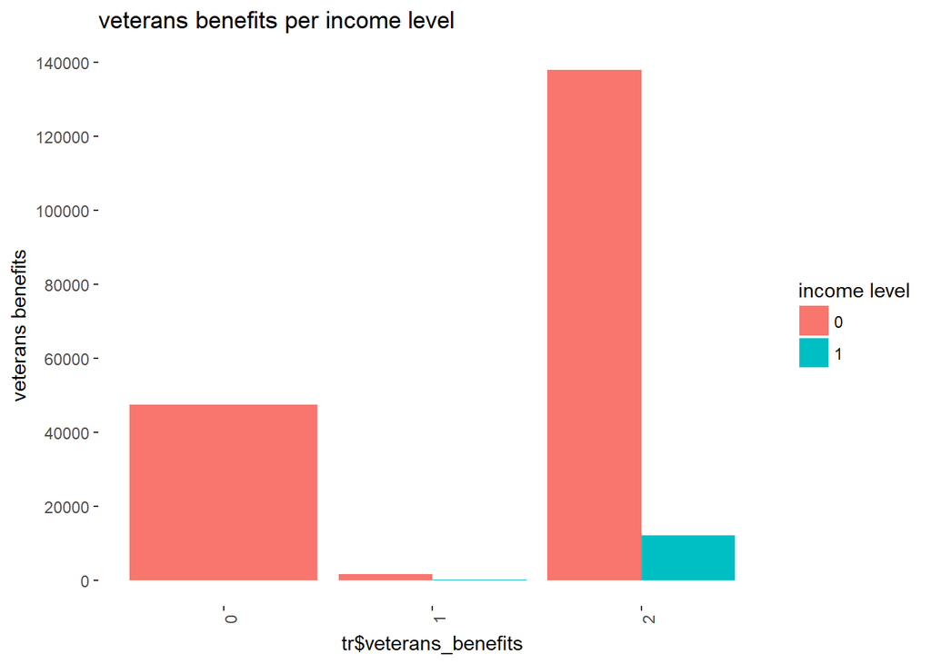

```r
ggplot(tr,aes(x = tr$veterans_benefits, fill = as.factor(income_level))) + geom_bar(position="dodge")+theme(panel.background = element_blank(),axis.text.x =element_text(angle  = 90,hjust = 1,size=9))+
  scale_y_continuous("veterans benefits", breaks = seq(0,150000,20000)) +
  ggtitle("veterans benefits per income level")+labs(fill = "income level")
```

#### 2.30 year

Same distribution of the income level for both years

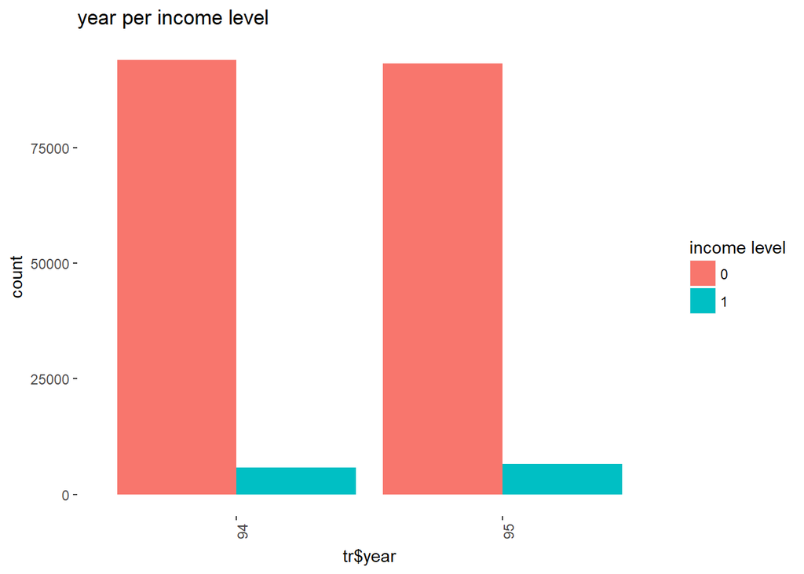

```r
ggplot(tr,aes(x = tr$year, fill = as.factor(income_level))) + geom_bar(position="dodge")+theme(panel.background = element_blank(),axis.text.x =element_text(angle  = 90,hjust = 1,size=9))+
  ggtitle("year per income level")+labs(fill = "income level")
```

Now after we have an initial idea for each variable, we are ready to start the next step **data cleaning and manipulation**.